# Racial Injustice Can Still be Seen in Mobile, Alabama

Josh Gladstone

```r
tracts <- read_csv("https://raw.githubusercontent.com/statsmaths/stat_data/gh-pages/acs_tract_data_2016.csv.gz")
```

```r
bama <- filter(tracts, cbsa == "Mobile, AL")
bama
```

```
## # A tibble: 112 x 88
##    state  county   cbsa     lon   lat population hh_income_q1 hh_income_q2
##    <chr>  <chr>    <chr>  <dbl> <dbl>      <int>        <int>        <int>
##  1 Alaba… Mobile … Mobil… -88.1  30.7        796         8419        12647
##  2 Alaba… Mobile … Mobil… -88.1  30.7       1652         6828        19230
##  3 Alaba… Mobile … Mobil… -88.1  30.7       1458         2262         8352
##  4 Alaba… Mobile … Mobil… -88.1  30.7       2745         5466        17586
##  5 Alaba… Mobile … Mobil… -88.1  30.7       4008        17331        48798
##  6 Alaba… Mobile … Mobil… -88.2  30.7       3949         7717        20514
##  7 Alaba… Mobile … Mobil… -88.1  30.8       1100         1652         9188
##  8 Alaba… Mobile … Mobil… -88.2  30.7       8071        13464        35698
##  9 Alaba… Mobile … Mobil… -88.1  30.7       1398         3516        12010
## 10 Alaba… Mobile … Mobil… -88.0  30.7       1238         6483        13972
## # ... with 102 more rows, and 80 more variables: hh_income_q3 <int>,
## #   hh_income_q4 <int>, hh_income_q5 <int>, hh_income_top_5 <dbl>,
## #   hh_gini <dbl>, median_rent <int>, sex_male <dbl>, sex_female <dbl>,
## #   age_00_17 <dbl>, age_18_24 <dbl>, age_25_59 <dbl>, age_60_plus <dbl>,
## #   race_white <dbl>, race_black <dbl>, race_ntvam <dbl>,
## #   race_asian <dbl>, race_pacif <dbl>, race_other <dbl>,
## #   race_multi <dbl>, born_same_st <dbl>, born_other_ne <dbl>,
## #   born_other_midwest <dbl>, born_other_south <dbl>,
## #   born_other_west <dbl>, commute_car <dbl>, commute_public <dbl>,
## #   commute_bike <dbl>, commute_walk <dbl>, commute_athome <dbl>,
## #   leave_0000_0459 <dbl>, leave_0500_0529 <dbl>, leave_0530_0559 <dbl>,
## #   leave_0600_0629 <dbl>, leave_0629_0659 <dbl>, leave_0700_0729 <dbl>,
## #   leave_0730_0759 <dbl>, leave_0800_0829 <dbl>, leave_0829_0859 <dbl>,
## #   leave_0900_0959 <dbl>, leave_1000_1059 <dbl>, leave_1100_1159 <dbl>,
## #   leave_1200_1559 <dbl>, leave_1600_2359 <dbl>, ctime_00_05 <dbl>,
## #   ctime_05_09 <dbl>, ctime_10_14 <dbl>, ctime_15_19 <dbl>,
## #   ctime_20_24 <dbl>, ctime_25_29 <dbl>, ctime_30_34 <dbl>,
## #   ctime_35_39 <dbl>, ctime_40_44 <dbl>, ctime_45_59 <dbl>,
## #   ctime_60_89 <dbl>, ctime_90_99 <dbl>, income_000_010 <dbl>,
## #   income_010_015 <dbl>, income_015_020 <dbl>, income_020_025 <dbl>,
## #   income_025_030 <dbl>, income_030_035 <dbl>, income_035_040 <dbl>,
## #   income_040_045 <dbl>, income_045_050 <dbl>, income_050_060 <dbl>,
## #   income_060_075 <dbl>, income_075_100 <dbl>, income_100_125 <dbl>,
## #   income_125_150 <dbl>, income_150_200 <dbl>, income_200_999 <dbl>,
## #   rent_by_income_00_10 <dbl>, rent_by_income_10_15 <dbl>,
## #   rent_by_income_15_20 <dbl>, rent_by_income_20_25 <dbl>,
## #   rent_by_income_25_30 <dbl>, rent_by_income_30_35 <dbl>,
## #   rent_by_income_35_40 <dbl>, rent_by_income_40_50 <dbl>,
## #   rent_by_income_50_99 <dbl>
```

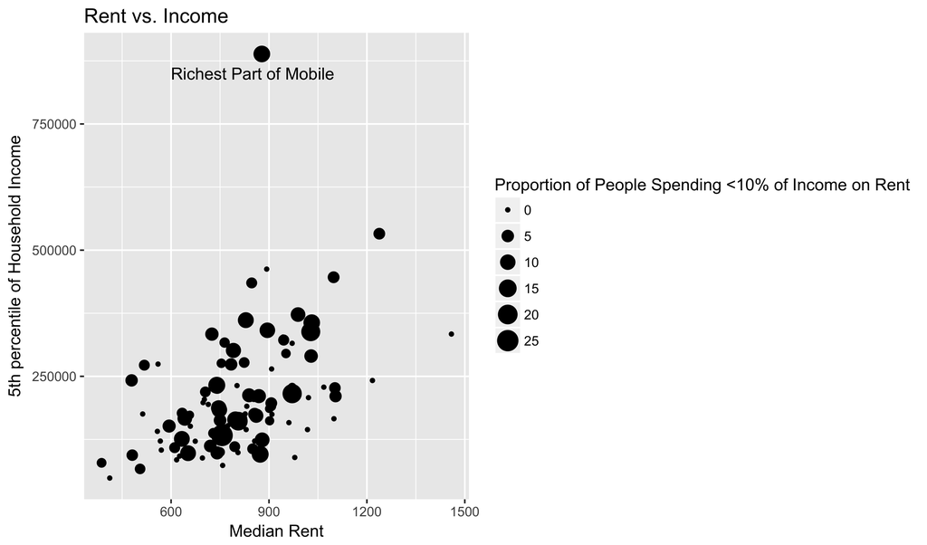

```r
ggplot(bama,aes(median_rent,hh_income_top_5))+
  geom_point(aes(size=rent_by_income_00_10)) +
  xlab("Median Rent")+
  ylab("5th percentile of Household Income")+
  ggtitle("Rent vs. Income")+
    annotate("text", x = 850, y = 850000,
           label = "Richest Part of Mobile")+
  labs(size="Proportion of People Spending <10% of Income on Rent")
```

When taking at in depth look at Mobile county in Alabama, we can draw some important conclusions. First, in general, there is a positive relationship between the 5th percentile of household income and the median rent. Areas with a richer top 5% tend to me able to pay more in rent which makes sense because the richer the people are in an area the more they can afford to pay in rent. Additionally, we can see that in richer areas with a higher 5th percentile of household income, there are more people that are paying only 0-10 percent of their income on rent. This means that within many of these rich areas, the people have a lot more money to spend on other things besides rent. We can see that their seems to be one significant point on this graph, which is by far the richest area in Mobile in terms of household income. This is the area with the coordinates (-88.15838,30.68456). This area also has one of the highest gini coefficients of 0.5301. Gini coefficient measures income inequality, and the higher the gini coefficient the more income inequality there is in a area. This value has to be between 0 and 1. This make sense because in this particular part of Mobile the data is probably skewed right towards the very rich top 5%.

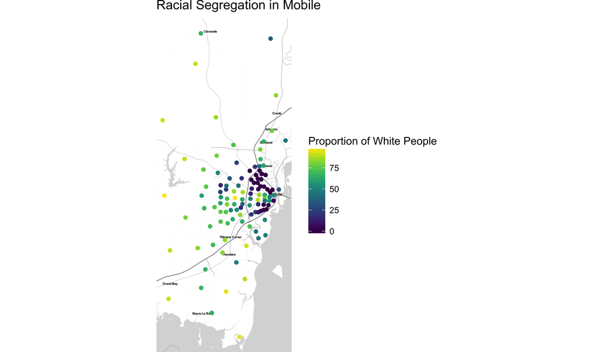

```r
qmplot(lon, lat, data = bama, geom = "blank")+
    geom_point(aes(color =race_white))+
  scale_color_viridis()+
  ggtitle("Racial Segregation in Mobile")+
  labs(color="Proportion of White People")
```

We can see from this graph that the majority of the white people live on the outskirts of the city farther away from the water. The majority of non-white people tend to live closer to the water and more towards the center of the city. This could be due to white flight which occured in many cities in the 1960s. This was basically when white people started to move to the suburbs or the outskirts of the city when the black people started to move into the center of the city. There are no places far outside the city with less than 25% of white people, so this shows that the areas that tend to have more non-white people are closer to the center of the city. Evidently, from this map, we can see that racial segregation still seems to be pretty prevalent in Mobile. The next graph will show how race can also affect income.

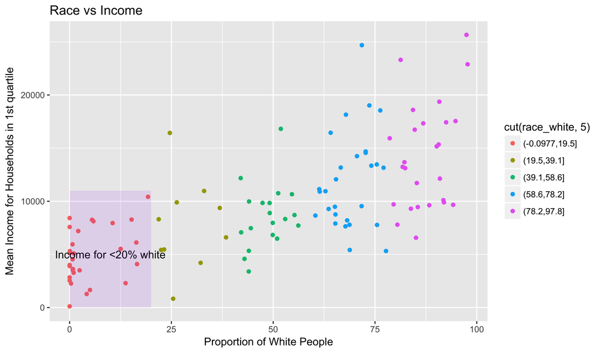

```r
ggplot(bama,aes(race_white, hh_income_q1))+
      geom_point(aes(color = cut(race_white, 5)))+
 ylab("Mean Income for Households in 1st quartile")+
  xlab("Proportion of White People")+
  ggtitle("Race vs Income")+
  annotate("text", x = 10, y = 5000,
           label = "Income for <20% white")+
    annotate("rect", xmin = 0, xmax = 20,
                   ymin = 0, ymax = 11000,
                   fill = "purple", alpha = 0.1)
```

Next, we can also see the income discrepancy in terms of different races. In general, the higher the proportion of white people in an area, the higher the mean income is in the first quartile. We can see from the graph that areas where there are less than 19.5 percent white people, only one mean income in the 1st quartile is over $10,000. This means that in these areas at least 25% of people make less than $10,000 per year. It is almost impossible to make a living off this low of an income, and this shows how poor some parts of Mobile are. Additionally, only one area in Mobile has a mean 1st quartile income of over $25,000 so this shows how much poverty exists in the area for the bottom 25% of people.

In conclusion, this data helps us see many important things in Mobile which I will reiterate below. First, Mobile is an area with income inequality amongst different races. Generally, areas with more white people tend to be richer than areas with less white people. This could be due to job discrimination or differences in the quality of education that people receive in certain areas of Mobile. The governor should certainly look at this problem and figure out a way to correct this problem. Mobile also has a very low mean income within their 1st quartile and many people are making less than $10,000 per year. The fact that Mobile is a poorer city in general can be shown by the fact that the median household income in Mobile is $45,744, compared to the national average of $57,617. Mobile is even lower than the Alabama average which is $46,257. Additionally, when looking at per capita income Mobile is $24,999 whereas the US average is $31,128. As a state, Alabama has the 7th highest gini coefficient which is 0.472. This means that Alabama has more income inequality than most other states in our country.

## References

“List of U.S States by Gini Coefficient .” Wikipedia, en.wikipedia.org/wiki/List_of_U.S._states_by_Gini_coefficient.